# Warsztaty Badawcze - Imputacja - PD1

Dawid Przybyliński

March 16, 2020

## 1. Zbiór danych

Badany zbiór to *breast-w* z OpenML. Zawiera on informacje o raku piersi 699 pacjentek. Zmienną celu jest informacja czy rak jest złośliwy czy też nie. Braki danych występują w kolumnie *Bare_Nuclei* - jest ich 16. Wobec tego sprawdzimy czy tak mała liczba brakujących danych może mieć jakikolwiek zauważalny wpływ na wyniki algorytmu uczenia maszynowego.

Braki danych początkowo oznaczone znakami zapytania, po poprawieniu tego przyjrzyjmy się kwantylom kolumn:

```r
dane$Bare_Nuclei[dane$Bare_Nuclei=="?"] <- NA
summary(dane)
```

```
##  Clump_Thickness  Cell_Size_Uniformity Cell_Shape_Uniformity Marginal_Adhesion
##  Min.   : 1.000   Min.   : 1.000       Min.   : 1.000        Min.   : 1.000
##  1st Qu.: 2.000   1st Qu.: 1.000       1st Qu.: 1.000        1st Qu.: 1.000
##  Median : 4.000   Median : 1.000       Median : 1.000        Median : 1.000
##  Mean   : 4.418   Mean   : 3.134       Mean   : 3.207        Mean   : 2.807
##  3rd Qu.: 6.000   3rd Qu.: 5.000       3rd Qu.: 5.000        3rd Qu.: 4.000
##  Max.   :10.000   Max.   :10.000       Max.   :10.000        Max.   :10.000
##
##  Single_Epi_Cell_Size  Bare_Nuclei  Bland_Chromatin  Normal_Nucleoli
##  Min.   : 1.000       1      :402   Min.   : 1.000   Min.   : 1.000
##  1st Qu.: 2.000       10     :132   1st Qu.: 2.000   1st Qu.: 1.000
##  Median : 2.000       2      : 30   Median : 3.000   Median : 1.000
##  Mean   : 3.216       5      : 30   Mean   : 3.438   Mean   : 2.867
##  3rd Qu.: 4.000       3      : 28   3rd Qu.: 5.000   3rd Qu.: 4.000
##  Max.   :10.000       (Other): 61   Max.   :10.000   Max.   :10.000
##                       NA's   : 16
##     Mitoses             Class
##  Min.   : 1.000   benign   :458
##  1st Qu.: 1.000   malignant:241
##  Median : 1.000
##  Mean   : 1.589
##  3rd Qu.: 1.000
##  Max.   :10.000
##
```

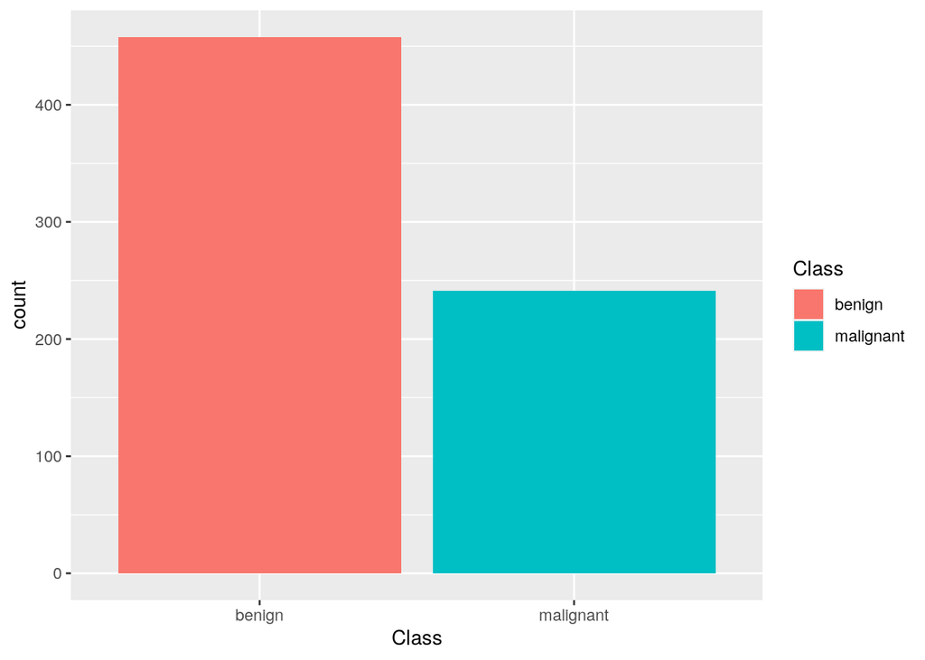

```r
ggplot(dane) +
  geom_bar(aes(x=Class, fill=Class))
```

```r
# benign - łagodny, niezłośliwy
# malignant - złośliwy
```

Poszukajmy zależności między między kolumną *Bare_Nuclei* a zmienną celu:

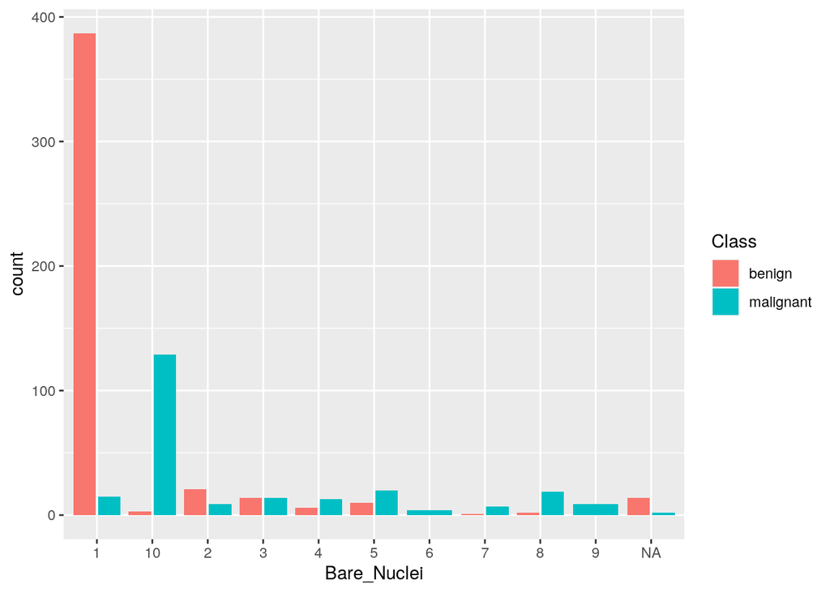

```r
ggplot(dane) +
  geom_histogram(aes(x=Bare_Nuclei, fill=Class), stat="count", position = "dodge2")
```

Okazuje się, że przy wartości tej kolumny bliskiej 1, rak często jest niezłośliwy, natomiast dla coraz bliższych wartości 10, większość przypadków to raki złośliwe. Brakujące dane w tej kolumnie mogą zatem okazać się ważne dla algorytmów klasyfikacji.

## 2. Model

Używany jest model *Recursive partitioning* czyli pojedyncze drzewo klasyfikacji.

```r
learner = mlr_learners$get("classif.rpart")

learner$param_set$values = mlr3misc::insert_named(
  learner$param_set$values,
  list(cp = 0.02, minsplit = 2, maxdepth = 15)
)

check_accuracy <- function(data_set){
  task_breast = TaskClassif$new(id = "breast", backend = data_set, target = "Class")
  train_set = sample(task_breast$nrow, 0.75 * task_breast$nrow)
  test_set = setdiff(seq_len(task_breast$nrow), train_set)
  learner$train(task_breast, row_ids = train_set)

  prediction = learner$predict(task_breast, row_ids = test_set)
  c(sum(prediction$truth==prediction$response),length(prediction$truth))
}

check_accuracy(dane)  # cały zbiór
```

```
## [1] 165 175
```

## 3. Algorytm po pozbyciu się braków danych

### 3.1 Usunięcie kolumny z brakującymi danymi

```r
check_accuracy(dane[,-6])    # zbiór bez kolumny
```

```
## [1] 156 175
```

### 3.2 Usunięcie wierszy z brakującymi danymi

```r
missing_rows <- which(is.na(dane$Bare_Nuclei))
check_accuracy(dane[-missing_rows,]) # zbiór bez wierszy z brakującą wartością
```

```
## [1] 156 171
```

### 3.3 Zastąpienie braków danych medianą

```r
median(as.numeric(dane$Bare_Nuclei), na.rm = TRUE)
```

```
## [1] 2
```

```r
dane_median <- dane
dane_median$Bare_Nuclei[is.na(dane_median$Bare_Nuclei)] <- median(as.numeric(dane$Bare_Nuclei), na.rm = TRUE)
check_accuracy(dane_median)
```

```
## [1] 166 175
```

### 3.4 Zastąpienie braków danych modą

```r
Mode <- function(x) {
  ux <- unique(x)
  ux[which.max(tabulate(match(x, ux)))]
}

Mode(dane$Bare_Nuclei)
```

```
## [1] 1
## Levels: ? 1 10 2 3 4 5 6 7 8 9
```

```r
dane_mode <- dane
dane_mode$Bare_Nuclei[is.na(dane_mode$Bare_Nuclei)] <- Mode(dane$Bare_Nuclei)
check_accuracy(dane_mode)
```

```
## [1] 163 175
```

## 4. Wyniki

|  | 1 | 2 | 3 | 4 | 5 | 6 | 7 | 8 | 9 | 10 | średnia |
| --- | --- | --- | --- | --- | --- | --- | --- | --- | --- | --- | --- |
| surowe_dane | 0.949 | 0.926 | 0.949 | 0.949 | 0.949 | 0.937 | 0.943 | 0.949 | 0.931 | 0.937 | 0.942 |
| bez_kolumny | 0.931 | 0.931 | 0.897 | 0.960 | 0.949 | 0.931 | 0.943 | 0.909 | 0.926 | 0.937 | 0.931 |
| bez_wiersza | 0.901 | 0.936 | 0.918 | 0.924 | 0.942 | 0.953 | 0.947 | 0.942 | 0.930 | 0.912 | 0.930 |
| z_medianą | 0.931 | 0.920 | 0.937 | 0.966 | 0.949 | 0.943 | 0.937 | 0.977 | 0.966 | 0.937 | 0.946 |
| z_modą | 0.909 | 0.931 | 0.937 | 0.897 | 0.931 | 0.943 | 0.943 | 0.931 | 0.909 | 0.926 | 0.926 |

## 5. Wnioski

Pozbycie się całej kolumny lub wiersza obniża skuteczność algorytmu - nic zaskakujacego, biorąc pod uwagę utratę sporej części danych. Podmienienie brakujących danych zadziałało najlepiej jeśli do podmiany używaliśmy mediany. Imputacja przy użyciu mody pogorszyła jakość działania algorytmu.